# 19200349

Harshad Kumar Elangovan

11/08/2020

```r
set.seed('19200349')

library(readr)
library(tibble)
library(dplyr)
library(tidyr)
library(magrittr)
```

```r
library(ggplot2)
library(shiny)
library(ggiraph)
library(lubridate)
library(gganimate)
library(reshape2)
```

#### 1. Import the dataset exo_data.csv as a tibble. Columns 1, 16, 17, 18, 25 should be characters. Columns 2, 14 should be factors. Column 15 should be integers. The remaining columns should be doubles.

```r
expodataset <- read_csv("exo_data.csv") #  the dataset is loaded as a tibble
class(expodataset)
```

```
## [1] "spec_tbl_df" "tbl_df"      "tbl"         "data.frame"
```

```r
is_tibble(expodataset)
```

```
## [1] TRUE
```

```r
str(expodataset)
```

```
## tibble [3,659 x 25] (S3: spec_tbl_df/tbl_df/tbl/data.frame)
##  $ id       : chr [1:3659] "KOI-1843.03" "Kepler-974 b" "KOI-1843.02" "Kepler-9 b" ...
##  $ flag     : num [1:3659] 0 0 0 0 0 0 0 0 0 0 ...
##  $ mass     : num [1:3659] 0.0014 NA NA 0.25 0.17 0.022 0.0321 NA 0.6 5.21 ...
##  $ radius   : num [1:3659] 0.054 0.14 0.071 0.84 0.82 0.147 NA 0.192 1.24 NA ...
##  $ period   : num [1:3659] 0.177 4.194 6.356 19.224 39.031 ...
##  $ axis     : num [1:3659] 0.0048 0.039 0.052 0.143 0.229 0.0271 0.053 NA 0.0449 1.33 ...
##  $ ecc      : num [1:3659] NA NA NA 0.0626 0.0684 NA 0.06 NA NA 0.15 ...
##  $ per      : num [1:3659] NA NA NA NA NA ...
##  $ lon      : num [1:3659] NA NA NA NA NA NA NA NA NA NA ...
##  $ asc      : num [1:3659] NA NA NA NA NA NA NA NA NA NA ...
##  $ incl     : num [1:3659] 72 89.4 88.2 87.1 87.2 ...
##  $ temp     : num [1:3659] NA NA NA 707 558 ...
##  $ age      : logi [1:3659] NA NA NA NA NA NA ...
##  $ meth     : chr [1:3659] "transit" "transit" "transit" "transit" ...
##  $ year     : num [1:3659] 2012 NA NA 2010 2010 ...
##  $ recency  : chr [1:3659] "13/07/15" "17/11/28" NA "15/12/03" ...
##  $ r_asc    : chr [1:3659] "19 00 03.14" "19 00 03.14" "19 00 03.14" "19 02 17" ...
##  $ decl     : chr [1:3659] "+40 13 14.7" "+40 13 14.7" "+40 13 14.7" "+38 24 03" ...
##  $ dist     : num [1:3659] NA NA NA 650 650 ...
##  $ host_mass: num [1:3659] 0.52 0.52 0.52 1.07 1.07 1.07 0.69 0.83 1.07 0.82 ...
##  $ host_rad : num [1:3659] 0.5 0.5 0.5 1.02 1.02 1.02 NA 0.79 NA NA ...
##  $ host_met : num [1:3659] 0.07 0.07 0.07 0.12 0.12 0.12 NA -0.01 -0.02 -0.18 ...
##  $ host_temp: num [1:3659] 3687 3687 3687 5777 5777 ...
##  $ host_age : num [1:3659] NA NA NA NA NA NA NA NA NA NA ...
##  $ lists    : chr [1:3659] "Controversial" "Confirmed planets" "Controversial" "Confirmed planets" ...
##  - attr(*, "problems")= tibble [2 x 5] (S3: tbl_df/tbl/data.frame)
##   ..$ row     : int [1:2] 1712 2970
##   ..$ col     : chr [1:2] "age" "age"
##   ..$ expected: chr [1:2] "1/0/T/F/TRUE/FALSE" "1/0/T/F/TRUE/FALSE"
##   ..$ actual  : chr [1:2] "0.0055" "3.0"
##   ..$ file    : chr [1:2] "'exo_data.csv'" "'exo_data.csv'"
##  - attr(*, "spec")=
##   .. cols(
##   ..   id = col_character(),
##   ..   flag = col_double(),
##   ..   mass = col_double(),
##   ..   radius = col_double(),
##   ..   period = col_double(),
##   ..   axis = col_double(),
##   ..   ecc = col_double(),
##   ..   per = col_double(),
##   ..   lon = col_double(),
##   ..   asc = col_double(),
##   ..   incl = col_double(),
##   ..   temp = col_double(),
##   ..   age = col_logical(),
##   ..   meth = col_character(),
##   ..   year = col_double(),
##   ..   recency = col_character(),
##   ..   r_asc = col_character(),
##   ..   decl = col_character(),
##   ..   dist = col_double(),
##   ..   host_mass = col_double(),
##   ..   host_rad = col_double(),
##   ..   host_met = col_double(),
##   ..   host_temp = col_double(),
##   ..   host_age = col_double(),
##   ..   lists = col_character()
##   .. )
```

```r
str(expodataset[,c(1,16,17,18,25)])
```

```
## tibble [3,659 x 5] (S3: tbl_df/tbl/data.frame)
##  $ id     : chr [1:3659] "KOI-1843.03" "Kepler-974 b" "KOI-1843.02" "Kepler-9 b" ...
##  $ recency: chr [1:3659] "13/07/15" "17/11/28" NA "15/12/03" ...
##  $ r_asc  : chr [1:3659] "19 00 03.14" "19 00 03.14" "19 00 03.14" "19 02 17" ...
##  $ decl   : chr [1:3659] "+40 13 14.7" "+40 13 14.7" "+40 13 14.7" "+38 24 03" ...
##  $ lists  : chr [1:3659] "Controversial" "Confirmed planets" "Controversial" "Confirmed planets" ...
##  - attr(*, "problems")= tibble [2 x 5] (S3: tbl_df/tbl/data.frame)
##   ..$ row     : int [1:2] 1712 2970
##   ..$ col     : chr [1:2] "age" "age"
##   ..$ expected: chr [1:2] "1/0/T/F/TRUE/FALSE" "1/0/T/F/TRUE/FALSE"
##   ..$ actual  : chr [1:2] "0.0055" "3.0"
##   ..$ file    : chr [1:2] "'exo_data.csv'" "'exo_data.csv'"
```

```r
str(expodataset[,c(2,14)])
```

```
## tibble [3,659 x 2] (S3: tbl_df/tbl/data.frame)
##  $ flag: num [1:3659] 0 0 0 0 0 0 0 0 0 0 ...
##  $ meth: chr [1:3659] "transit" "transit" "transit" "transit" ...
##  - attr(*, "problems")= tibble [2 x 5] (S3: tbl_df/tbl/data.frame)
##   ..$ row     : int [1:2] 1712 2970
##   ..$ col     : chr [1:2] "age" "age"
##   ..$ expected: chr [1:2] "1/0/T/F/TRUE/FALSE" "1/0/T/F/TRUE/FALSE"
##   ..$ actual  : chr [1:2] "0.0055" "3.0"
##   ..$ file    : chr [1:2] "'exo_data.csv'" "'exo_data.csv'"
```

```r
str(expodataset[,15])
```

```
## tibble [3,659 x 1] (S3: tbl_df/tbl/data.frame)
##  $ year: num [1:3659] 2012 NA NA 2010 2010 ...
##  - attr(*, "problems")= tibble [2 x 5] (S3: tbl_df/tbl/data.frame)
##   ..$ row     : int [1:2] 1712 2970
##   ..$ col     : chr [1:2] "age" "age"
##   ..$ expected: chr [1:2] "1/0/T/F/TRUE/FALSE" "1/0/T/F/TRUE/FALSE"
##   ..$ actual  : chr [1:2] "0.0055" "3.0"
##   ..$ file    : chr [1:2] "'exo_data.csv'" "'exo_data.csv'"
```

```r
# converting the required columns as factor
colnames(expodataset[,c(2,14)])
```

```
## [1] "flag" "meth"
```

```r
expodataset$flag %<>% as.factor
expodataset$meth %<>% as.factor


# converting the required columns to integer
colnames(expodataset[,15])
```

```
## [1] "year"
```

```r
expodataset$year %<>% as.integer

# converting the required columns to character
colnames(expodataset[,c(1,16,17,18,25)])
```

```
## [1] "id"      "recency" "r_asc"   "decl"    "lists"
```

```r
expodataset$id %<>% as.character
expodataset$recency %<>% as.character
expodataset$r_asc %<>% as.character
expodataset$decl %<>% as.character
expodataset$lists %<>% as.character
```

#### 2. Exclude the exoplanets with an unknown method of discovery

```r
# We can drop rows containing missing values (unknown) of the method variable using is.na function

length(expodataset$meth)
```

```
## [1] 3659
```

```r
expodataset <- expodataset[!is.na(expodataset$meth), ]
length(expodataset$meth)
```

```
## [1] 3596
```

```r
# From the length diffeence, we see that around 63 rows are removed from the dataset.
```

#### 3. Create a graphic which illustrates the relationship between the log-distances from the Sun and the methods of discovery.

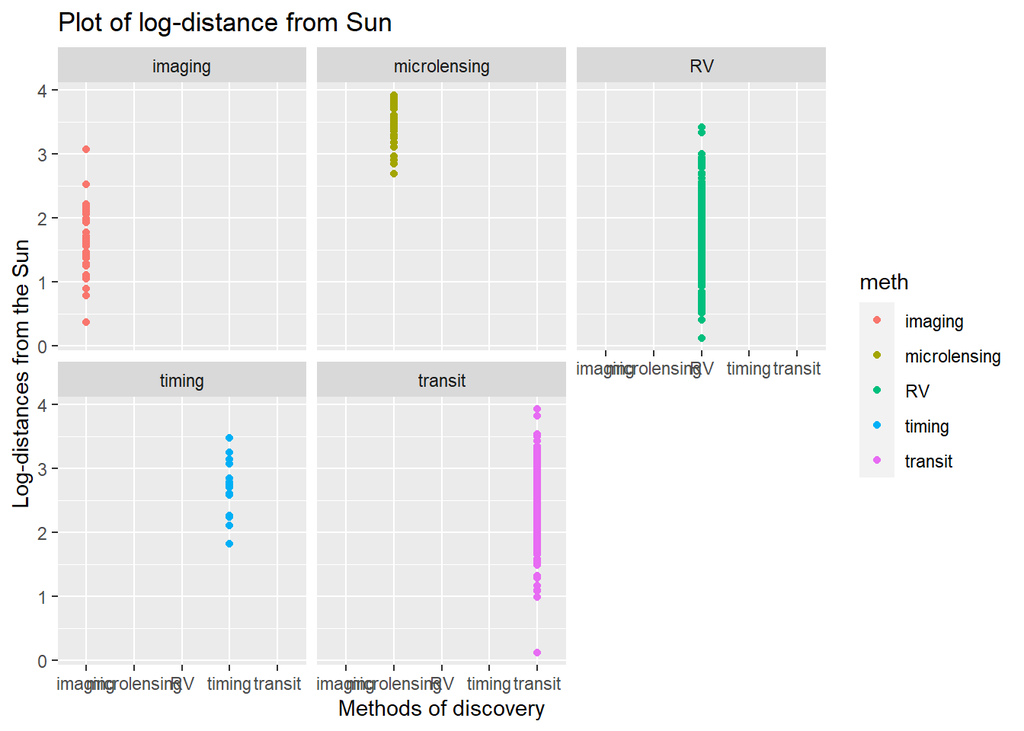

```r
ggplot(expodataset, aes(meth,log10(dist),col=meth)) +
  geom_point() +
  facet_wrap(~meth) +
  labs(
    title = "Plot of log-distance from Sun",
    x = 'Methods of discovery',
    y = 'Log-distances from the Sun')
```

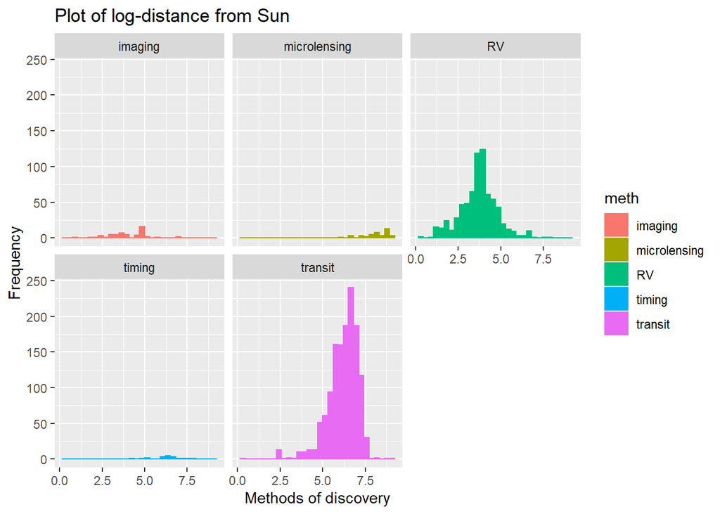

```r
ggplot(expodataset, aes(x = log(dist), fill = meth, color = meth)) +
  geom_histogram(position = "identity") +
  facet_wrap(~meth) +
  labs(
    title = "Plot of log-distance from Sun",
    x = 'Methods of discovery',
    y = 'Frequency')
```

#### 4. Create scatterplots of the log-mass versus log-distances, separating by methods of discovery. Hovering with the cursor highlights the point and displays its name, and, if you click, the exoplanet’s page on the Open Exoplanet Catalogue will be opened. (paste the id after http://www.openexoplanetcatalogue.com/planet/ ).

```r
expodataset$link <- sprintf("window.open(\"%s%s\")",
                              "http://www.openexoplanetcatalogue.com/planet/",
                              as.character(expodataset$id))

g2 <- ggplot(expodataset, aes(log10(mass),log10(dist), colour = as.factor(meth))) +
  xlab('Log-Masses') +
  ylab('Log-distances from the Sun') +
  scale_color_discrete(name="Methods of \nDiscovery")

p2 <- g2 + geom_point_interactive(aes(tooltip = id,
                                      data_id = id,
                                      onclick = link),alpha=0.5,
                                  size = 1.5)
ggiraph(code = print(p2), width = 0.8,tooltip_opacity = 0.5)
```

[interactive chart not shown]

#### 5. Rename the radius into jupiter_radius, and create a new column called earth_radius which is 11.2 times the Jupiter radius.

```r
colnames(expodataset[,4])
```

```
## [1] "radius"
```

```r
expodataset <- expodataset %>% rename(jupiter_radius = radius)
expodataset <- expodataset %>% mutate(earth_radius = 11.2 * jupiter_radius)
```

#### 6. Focus only on the rows where log-earth radius and log-period have no missing values, and perform kmeans with four clusters on these two columns.

```r
expodataset1 <- expodataset %>% drop_na(earth_radius, period)

radius_dataset <- expodataset1 %>% transmute(period = log(period),earth_radius = log(earth_radius))

kmeansmodel <- kmeans(radius_dataset, centers = 4)
# examine the results

table(kmeansmodel$cluster)
```

```
##
##    1    2    3    4
##  798  385  416 1133
```

#### 7. Add the clustering labels to the dataset through a new factor column called type, with levels rocky, hot_jupiters, cold_gas_giants, others; similarly to https: //en.wikipedia.org/wiki/Exoplanet#/media/File:ExoplanetPopulations-20170616. png and produce the scatterplot highlighting these clusters.

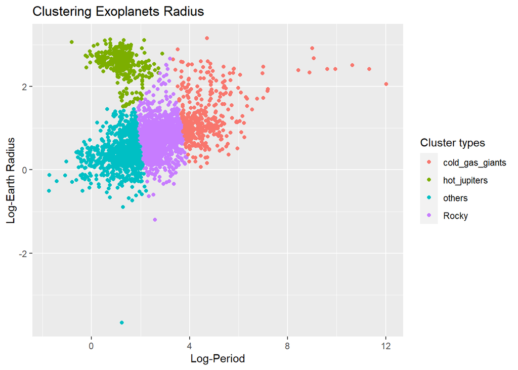

```r
kmeansmodel$cluster <- as.factor(kmeansmodel$cluster)

#ggplot(radius_dataset, aes(period, earth_radius, color = kmeansmodel$cluster)) +
#  geom_point() +
#  labs(title="Clustering solutions of Exoplanets") +
#  scale_color_discrete(name="Cluster types")


expodataset1$type <- kmeansmodel$cluster
expodataset1$type <- as.numeric(expodataset1$type)

expodataset1$type[expodataset1$type == 1] <- "others"
expodataset1$type[expodataset1$type == 2] <- "hot_jupiters"
expodataset1$type[expodataset1$type == 3] <- "cold_gas_giants"
expodataset1$type[expodataset1$type == 4] <- "Rocky"

ggplot(expodataset1, aes(log(period), log(earth_radius), color = type)) +
  geom_point() +
  xlab('Log-Period') +
  ylab('Log-Earth Radius') +
  labs(title="Clustering Exoplanets Radius") +
  scale_color_discrete(name="Cluster types")
```

```r
#table(kmeansmodel$cluster)

# CLustering Labels
table(expodataset1$type)
```

```
##
## cold_gas_giants    hot_jupiters          others           Rocky
##             416             385             798            1133
```

#### 8. Use a violin plot to illustrate how these clusters relate to the log-mass of the exoplanet.

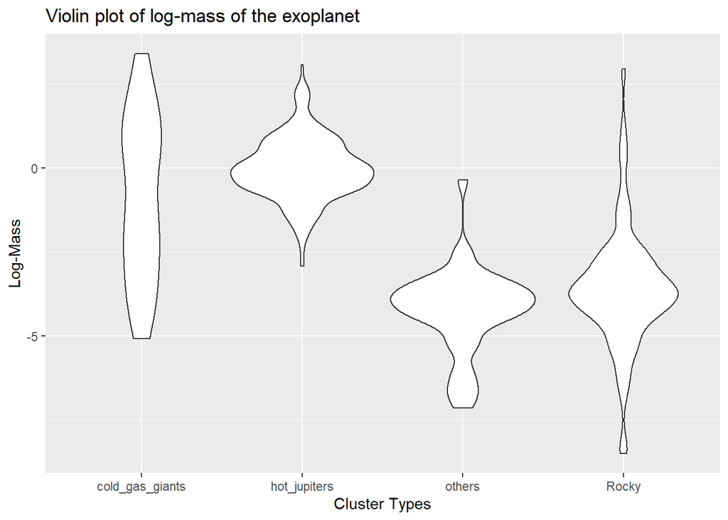

```r
ggplot(expodataset1, aes(x = type, y = log(mass))) +
      geom_violin(na.rm=TRUE) +
  xlab('Cluster Types') +
  ylab('Log-Mass') +
      labs(title = "Violin plot of log-mass of the exoplanet")
```

#### 9. Transform r_asc and decl into two new variables that are the same variables but in values of seconds. Use these as coordinates to represent a celestial map for the exoplanets.

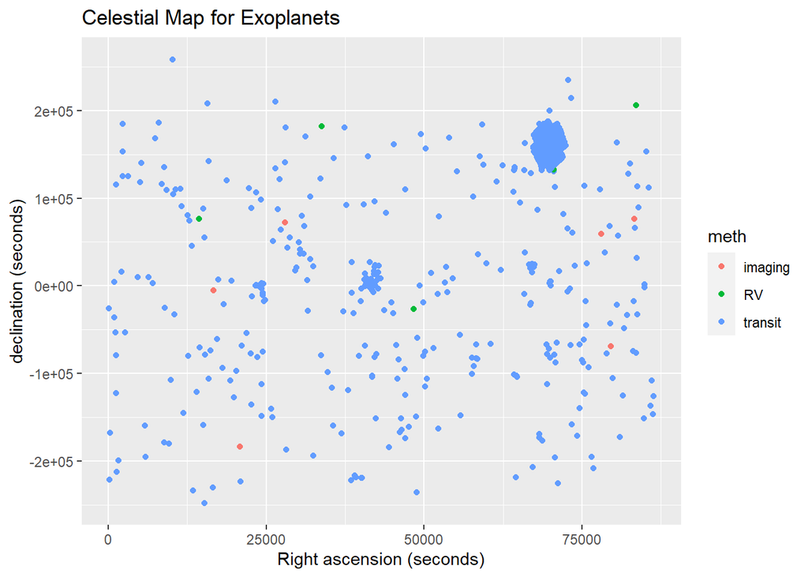

```r
expodataset1 <- expodataset1 %>% drop_na(r_asc,decl)
expodataset1$r_asc1 <- gsub(" ", ":", expodataset1$r_asc, fixed = TRUE)
expodataset1$r_asc1 <- hms(expodataset1$r_asc1)
expodataset1$r_asc1 <- period_to_seconds(expodataset1$r_asc1)

expodataset1$decl1 <- gsub(" ", ":", expodataset1$decl, fixed = TRUE)
expodataset1$decl1 <- hms(expodataset1$decl1)
expodataset1$decl1 <- period_to_seconds(expodataset1$decl1)

ggplot(expodataset1, aes(r_asc1, decl1, color= meth)) +
  geom_point() +
  labs(title="Celestial Map for Exoplanets",
       x="Right ascension (seconds)",
       y="declination (seconds)")
```

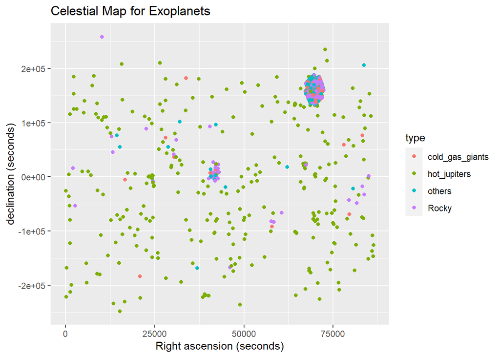

```r
#plotting with cluster types
ggplot(expodataset1, aes(r_asc1, decl1, color= type)) +
  geom_point() +
  labs(title="Celestial Map for Exoplanets",
       x="Right ascension (seconds)",
       y="declination (seconds)")
```

#### 10. Create an animated time series where multiple lines illustrate the evolution over time of the total number of exoplanets discovered for each method up to that year.

```r
exoplanets_count <- expodataset %>%
            group_by(meth, year) %>%
            summarise(Count = length(meth)) %>%
            mutate(Count = cumsum(Count))
```

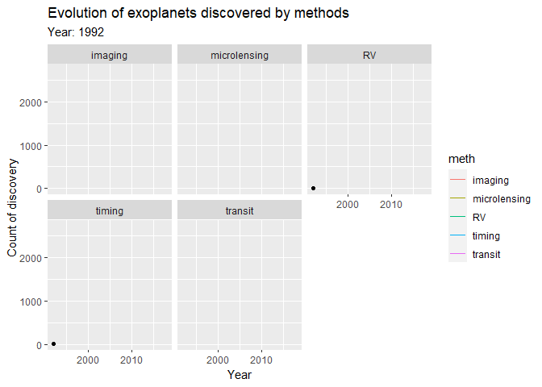

```r
exoplanets_count <- na.omit(exoplanets_count)

time_series<-ggplot(exoplanets_count, aes(x = year, y = Count, group = meth)) +
  geom_point() +
  geom_line(aes(color = meth)) +
  facet_wrap(~meth) +
  transition_reveal(year) +
  labs(title = 'Evolution of exoplanets discovered by methods',
       subtitle = 'Year: {frame_along}',
       x = 'Year',
       y = 'Count of discovery')

#t2<-ggplot(t1, aes(x = year, y = Count, group = meth)) +
#  geom_line(aes(color = meth)) +
#  geom_point(size = 2) +
#  facet_wrap(~meth) +
#  transition_reveal(year) +
#  labs(title = 'Evolution Total number of exoplanets discovered by methods',
#       subtitle = 'Year: {frame_along}',
#       y = 'Number Discovered')

animation <- animate(time_series, renderer = gifski_renderer(loop = T)) # check out docs for more options
animation
```

```r
#Using clusters - No productive response
#exoplanets_count1 <- expodataset1 %>%
#            group_by(type, year) %>%
#            summarise(Count = length(type)) %>%
#            mutate(Count = cumsum(Count))

#exoplanets_count1 <- na.omit(exoplanets_count)

#time_series1<-ggplot(exoplanets_count1, aes(x = year, y = Count, group = meth)) +
#  geom_line(aes(color = meth)) +
#  geom_point(size = 2) +
#  facet_wrap(~meth) +
#  transition_reveal(year) +
#  labs(title = 'Evolution of exoplanets discovered by methods',
#       subtitle = 'Year: {frame_along}',
#       x = 'Year',
#       y = 'Count of discovery')

#t2<-ggplot(t1, aes(x = year, y = Count, group = meth)) +
#  geom_line(aes(color = meth)) +
#  geom_point(size = 2) +
#  facet_wrap(~meth) +
#  transition_reveal(year) +
#  labs(title = 'Evolution Total number of exoplanets discovered by methods',
#       subtitle = 'Year: {frame_along}',
#       y = 'Number Discovered')

#animation1 <- animate(time_series1, renderer = gifski_renderer(loop = T)) # check out docs for more options
#animation1
```

#### 11. Create an interactive plot with Shiny where you can select the year (slider widget, with values ≥ 2009) and exoplanet type. Exoplanets appear as points on a scatterplot (log-mass vs log-distance coloured by method) only if they have already been discovered. If type is equal to all all types are plotted together.

```r
library(shiny)
library(knitr)

maxyr <-  max(expodataset1$year,na.rm = T)

ui <- shinyUI(
    fluidPage(
      # Application title
    titlePanel("Old Faithful Geyser Data"),

    # Sidebar with a slider input for number of bins
    sidebarLayout(
        sidebarPanel(
            sliderInput("year",
                        "Year:",
                        min = 2009,
                        max = maxyr,
                        value = 2010),

            selectInput("type",
                        label = "Type:",
                        choices = c('hot_jupiters', 'cold_gas_giants', 'Rocky', 'others','All'),
                        selected = 'cold_gas_giants')
        ),

        # Show a plot of the generated distribution
        mainPanel(
           plotOutput("distPlot")
        )
    )
  )
)

server <- function(input, output) {
    output$distPlot <- renderPlot({

        # generate bins based on input$bins from ui.R
        x    <- expodataset1
        x <- reactive({
                      if(input$type != 'All'){
                        expodataset1[((expodataset1$year <= input$year) & (expodataset1$type == input$type)),]
                      }
                      else {
                        expodataset1[(expodataset1$year <= input$year),]
                      }
                        #subset(x, year == input$year & type == input$type)
                      })
        #bins <- seq(min(x), max(x), length.out = input$bins + 1)

        # draw the histogram with the specified number of bins
        #hist(x, breaks = bins, col = 'darkgray', border = 'white')

        ggplot(x(), aes(x= log(mass),y = log(dist), color = meth)) +
          geom_point() +
            labs(
                 title = "Plot of Exoplanets discovered over years",
                 x = 'Log - Mass',
                 y = 'Log - Distance')

    })
}

shinyApp(ui, server)
```

Shiny applications not supported in static R Markdown documents

#### 12. Fit a linear regression model where log period is the response variable and the logs of host_mass, host_temp and axis are the covariates (exclude rows that contain at least one missing value). Include an intercept term in the regression model.

```r
expodataset2 <- expodataset1 %>% drop_na(mass,temp,axis)
fitlm <-lm(log(period) ~ log(mass) + log(temp) + log(axis), data = expodataset2)
summary(fitlm)
```

```
##
## Call:
## lm(formula = log(period) ~ log(mass) + log(temp) + log(axis),
##     data = expodataset2)
##
## Residuals:
##      Min       1Q   Median       3Q      Max
## -0.28421 -0.06576 -0.02123  0.02683  0.60051
##
## Coefficients:
##              Estimate Std. Error t value Pr(>|t|)
## (Intercept)  7.795781   0.159526  48.869  < 2e-16 ***
## log(mass)   -0.031775   0.005475  -5.804 1.77e-08 ***
## log(temp)   -0.307241   0.023473 -13.089  < 2e-16 ***
## log(axis)    1.406615   0.008817 159.532  < 2e-16 ***
## ---
## Signif. codes:  0 '***' 0.001 '**' 0.01 '*' 0.05 '.' 0.1 ' ' 1
##
## Residual standard error: 0.1468 on 277 degrees of freedom
## Multiple R-squared:  0.9919, Adjusted R-squared:  0.9918
## F-statistic: 1.127e+04 on 3 and 277 DF,  p-value: < 2.2e-16
```

From the summary statistics of the fitted model on log-period with covariates of log-mass,log-temp and log-axis, we see that all the three covariates are highly significant as 99% confidence level. A change in any of these three variables will impact the response variable period of the exoplanets.

The period variable in this dataset depicts the orbital period of the planet. From this model fit, we see that the covariates - mass, temp and axis are highly significant to the response variable period. This depicts that the orbital period of the planet will be affected if there are any change in the mass or temperature or axis of the planet.

#### 13. Include in your RMarkdown document some model summaries and an interpretation of the model you have fit.

```r
anova(fitlm)
```

```
## Analysis of Variance Table
##
## Response: log(period)
##            Df Sum Sq Mean Sq   F value    Pr(>F)
## log(mass)   1   0.43    0.43    19.979 1.142e-05 ***
## log(temp)   1 179.75  179.75  8343.827 < 2.2e-16 ***
## log(axis)   1 548.26  548.26 25450.392 < 2.2e-16 ***
## Residuals 277   5.97    0.02
## ---
## Signif. codes:  0 '***' 0.001 '**' 0.01 '*' 0.05 '.' 0.1 ' ' 1
```

Type 1 Analysis of Variance determines whether there is any statistically significant difference in the model by introducing new variables one by one to the model. The anova table shows that there is high significance by adding log - mass to the model. So it can be added to the model. Now, the second variable log - temp is added to the existing model and the table is compared to check if the new variable fits in the model. If the variable fits, then the next variable until last variable is added to the existing model and compared. So, it works in a sequential way with one variable at a time.

From the above table, all the three covariates have a higher significance on the response variable. So, these covariates can be used to model the dataset.

We can have a look at the qqplot to check the linear regression fit of the covariates on the response variable log - period.

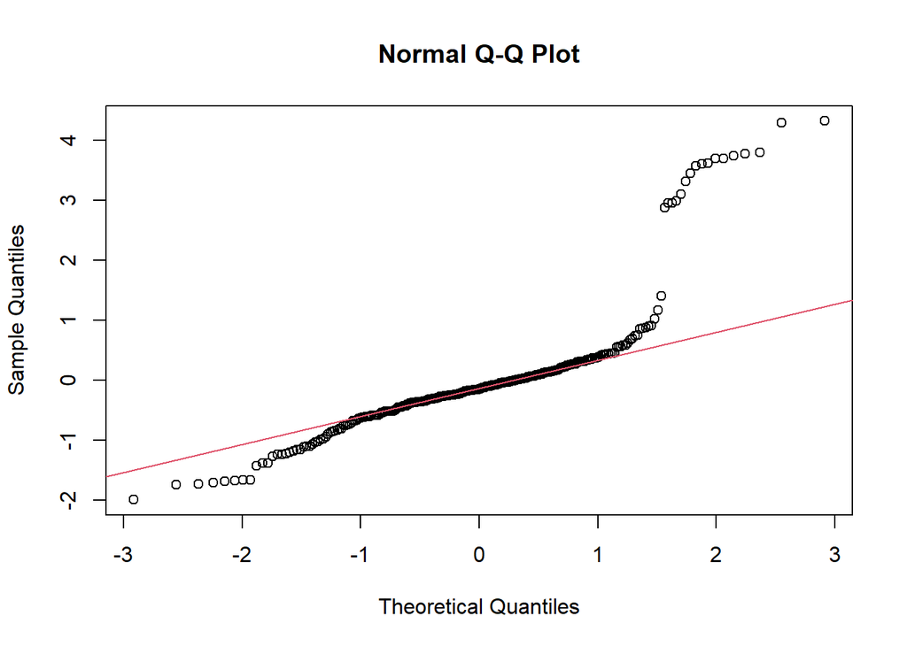

```r
qqnorm(rstudent(fitlm))
qqline(rstudent(fitlm),col=2)
```